# Teoria Regulacji, Wtorek 17:05-18:45

## Jan Bronicki 249011

### Zadanie 2 z Listy 2 ("mini-projekt")

Dla systemu o następującej transmitancji: $$ K(s) = \frac{1}{(s+1)(s+2)} $$ Należy wyznaczyć pobudzienie na wejście:

$u(t) = 1(t)$

Z następującymi warunkami początkowymi:

$y(0)=1$  
$y^{\prime}(0)=2$

System dodatkowo można przedstawić graficznie za pomocą schematu blokowego jako:

[figure not shown]

Na początku wiedząc, że $Y(s) = K(s) \cdot U(s)$ obliczamy $y_{1}(t)$:  
Gdzie za $U(s)$ podstawiamy to, czemu równałoby się $u(t)$ po transformacie Laplace'a:

$$ Y(s) = \frac{1}{(s+1)(s+2)} \cdot \frac{1}{s} $$$$ Y(s) = \frac{A}{s} + \frac{B}{s+1} + \frac{C}{s+2} $$\begin{cases} A=\frac{1}{2} \\ B=-1 \\ C=\frac{1}{2} \end{cases}$$ Y(s) = \frac{\frac{1}{2}}{s} + \frac{-1}{s+1} + \frac{\frac{1}{2}}{s+2} $$

Następnie stosująć wzory na odwrotną transformatę Laplace'a, uzyskujemy wynik w dziedzinie czasu:

$$ \mathcal{L}^{-1}\left\{Y(s)\right\} = \mathcal{L}^{-1}\left\{\frac{\frac{1}{2}}{s} + \frac{-1}{s+1} + \frac{\frac{1}{2}}{s+2}\right\} $$$$ y_{1}(t) = \frac{1}{2}e^{-2t} - e^{-t} + \frac{1}{2} $$

#### Możemy to osiągnąć również stosując bibliotekę taką jak SymPy umożliwiającą, nam używanie zapisów symbolicznych w Python'ie

```python
# Biblioteka SymPy
import sympy as sp
# NumPy uzywanany do numerycznych operacji matematycznych
import numpy as np
# Matplotlib sluzacy do wizualizacji
import matplotlib.pyplot as plt
```

```python
# Definiujemy obiekty biblioteki SymPy
t, y, s = sp.symbols('t y s')
# Tworzymy rownanie
Ys = 1/(s*(s+1)*(s+2))
Ys
```

$\displaystyle \frac{1}{s \left(s + 1\right) \left(s + 2\right)}$

Następnie dokonujemy rozbicia:

```python
Ys = Ys.apart()
Ys
```

$\displaystyle \frac{1}{2 \left(s + 2\right)} - \frac{1}{s + 1} + \frac{1}{2 s}$

```python
y1 = sp.expand(sp.inverse_laplace_transform(Ys.apart(), s, t))
y1
# theta(t) to 1(t) w bibliotece SymPy
```

$\displaystyle \frac{\theta\left(t\right)}{2} - e^{- t} \theta\left(t\right) + \frac{e^{- 2 t} \theta\left(t\right)}{2}$

Teraz możemy narysować rozwiązanie $y_{1}(t)$:

```python
'''
"time" bedzie nasza osia czasu,
a y1_time odpowiedza jaka dostaniemy w konkretnym punkcie czasu
'''
time = np.arange(0, 10, 0.01)
y1_time = np.arange(0, 10, 0.01)

y1_lambda = sp.lambdify(t, y1, modules=['numpy', 'sympy'])

for each in range(0, len(time)):
    y1_time[each] = y1_lambda(time[each])
```

Teraz możemy narysować wynik rozwiązania numerycznego poprzez, zamienienie równania symbolicznego biblioteki SymPy na funkcję (lambdę) w Pythonie z implementacją w NumPy'u dzięki funkcji:

```
sympy.utilities.lambdify(symfunc, implementation)
```

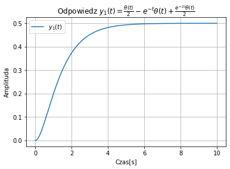

```python
plt.plot(time, y1_time, label=("$y_{1}(t)$"))
plt.grid(True)
plt.title("Odpowiedz "+"$"+"y_{1}(t) = "+sp.latex(y1)+"$")
plt.xlabel("Czas[s]")
plt.ylabel("Amplituda")
plt.legend()
plt.show()
```

#### Następnie na podstawie równania charakterystycznego $(s+1)(s+2)$ możemy dojść do oryginalnego równania różniczkowego:

$$Y(s) = \frac{1}{(s+1)(s+2)} \cdot \frac{1}{s}$$$$ Y(s)\left[s^{2}+3s+2\right] = \frac{1}{s}$$$$ y^{\prime\prime}+3y^{\prime}+2y=u(t) $$$$ s^{2}Y(s)-sy(0)-y^{\prime}+3sY(s)-3y(0)+2Y(s) = 0 $$

gdzie $y(0)=1$ oraz $y^{\prime}(0)=2 $

$$ Y(s) = \frac{s+5}{s^{2}+3s+2} $$$$ Y(s) = \frac{s+5}{(s+2)(s+1)} $$$$ Y(s) = \frac{A}{s+1}+\frac{B}{s+2} $$\begin{cases} A=4 \\ B=-3 \end{cases}$$ Y(s) = \frac{4}{s+1}+\frac{-3}{s+2} $$

Następnie stosujemy odwrotną transformatę Laplace'a:

$$ \mathcal{L}^{-1}\left\{Y(s)\right\} = \mathcal{L}^{-1}\left\{\frac{4}{s+1}+\frac{-3}{s+2}\right\} $$$$ y_{2}(t) = 4e^{-t}-3e^{-2t} $$

#### Następnie tak samo możemy postąpić w tym przypadku, używając możliwości symbolicznych obliczeń jakie daje nam Python

```python
Ys = (s+5)/((s**2)+3*s+2)
Ys
```

$\displaystyle \frac{s + 5}{s^{2} + 3 s + 2}$

```python
Ys = Ys.factor()
Ys
```

$\displaystyle \frac{s + 5}{\left(s + 1\right) \left(s + 2\right)}$

```python
Ys = Ys.apart()
Ys
```

$\displaystyle - \frac{3}{s + 2} + \frac{4}{s + 1}$

```python
y2 = sp.expand(sp.inverse_laplace_transform(Ys.apart(), s, t))
y2
```

$\displaystyle 4 e^{- t} \theta\left(t\right) - 3 e^{- 2 t} \theta\left(t\right)$

Teraz zamieniamy postać symboliczną na funkcję z, której uzyskamy wartości numeryczne:

```python
'''
"time" bedzie nasza osia czasu,
a y2_time odpowiedza jaka dostaniemy w konkretnym punkcie czasu
'''
time = np.arange(0, 10, 0.01)
y2_time = np.arange(0, 10, 0.01)

y2_lambda = sp.lambdify(t, y2, modules=['numpy', 'sympy'])

'''
Z powodu implementacji Heaviside w SymPy'u obecna funkcja nie bedzie mogla zostac wyliczona,
dla 0, dlatego wpisujemy jej wartosc, dla 0 reczne
'''
y2_time[0] = 1.0
for each in range(1, len(time)):
    y2_time[each] = y2_lambda(time[each])
```

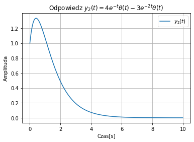

```python
plt.plot(time, y2_time, label=("$y_{2}(t)$"))
plt.grid(True)
plt.title("Odpowiedz "+"$"+"y_{2}(t) = "+sp.latex(y2)+"$")
plt.xlabel("Czas[s]")
plt.ylabel("Amplituda")
plt.legend()
plt.show()
```

#### Teraz możemy końcowo dodać nasze dwie otrzymane funkcje $y_{1}(t)$ oraz $y_{2}(t)$:

$$ y(t) = y_{1}(t) + y_{2}(t) = 3e^{-t} - \frac{5}{2}e^{-2t} + \frac{1}{2} $$

Następnie rysujemy otrzymane $y(t)$ wraz z $y_{1}(t) + y_{2}(t)$, dla porównania:

```python
y = y1+y2
y
```

$\displaystyle \frac{\theta\left(t\right)}{2} + 3 e^{- t} \theta\left(t\right) - \frac{5 e^{- 2 t} \theta\left(t\right)}{2}$

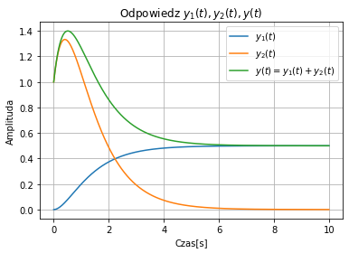

```python
# y1(t)
plt.plot(time, y1_time, label=("$y_{1}(t)$"))

# y2(t)
plt.plot(time, y2_time, label=("$y_{2}(t)$"))

plt.plot(time, y1_time+y2_time, label=("$y(t)=y_{1}(t)+y_{2}(t)$"))
plt.grid(True)
plt.title("Odpowiedz "+"$"+"y_{1}(t), y_{2}(t), y(t)"+"$")
plt.xlabel("Czas[s]")
plt.ylabel("Amplituda")
plt.legend()
plt.show()
```

### Przykład zastosowania

Przykładem zjawiska fizycznego, które jest opisywane za pomocą równania różniczkoweo drugiego stopnia jest sprężyna, której drgania są tłumione przez otoczenie (np.: gęsty gaz, ciecz itp.). Taka sprężyna jest zwykle opisana w następujący sposób:

$$ mx^{\prime\prime}(t)+bx^{\prime}(t)+kx(t) = 0$$

Gdzie:

- m - masa
- b - stała np. współczcynnik tarcia, charakterystyczny, dla otoczenia
- k - stała np. współczynnik sprężystości, charakterystyczny, dla sprężyny
- $x(t)$ - jest wtedy pozycją na osi $x$
- $x^{\prime}(t)$ - jest wtedy prędkością na osi $x$
- $x^{\prime\prime}(t)$ - jest wtedy przyspieszeniem na osi $x$

Zajwiska opisywane tego stopnia równaniem są prawdopodobnie najczęściej spotykanymi.

### Wnioski

Matematyczny opis modeli fizycznych jest bardzo przydatny w inżynierii, pozwala nam opisać oraz przewidzieć zachowanie jakiegoś systemu. Zwłaszcza dzięki rozwiązaniom numerycznym, rysując odpowiedź jakiegoś modelu na jakieś wejście, dzieki takiej wizualizacji bardzo łatwo nam jest zrozumieć model.

Dodatkowo uważam, że forma zadania jest bardzo ciekawa, ale prosiłbym o więcej szczegółów apropos tego co Pan oczekuje/w jaki sposob Pan oczekuje, że wykonamy zadanie.